# 2218_Yilong_mRNA_stressGranules_CIRIquantDESeq2

# 1. Sample sheet and background

# 2. Load libraries

# 3. Create dds unfiltered object

This workflow uses the *DESeq2* R packages. We can start from the counts summarized at gene level, found in:

## 3.a) Load the data

```r
dfolder <- "/data/processing3/balan/projects/2218_Yilong_part2/analysis_CIRI2_full/without_CIRI_DE/"
fcounts_gene <- "gene_count_matrix.csv"
fcounts_transcripts <- "transcript_count_matrix.csv"

dfcounts_gene <- read.delim(paste0(dfolder, fcounts_gene), header = TRUE, sep=',', na.strings="NA" )#, row.names=1) needs work later
dfcounts_transcripts <- read.delim(paste0(dfolder, fcounts_transcripts), header = TRUE, sep=',', na.strings="NA", row.names=1)
```

There are 58302 genes/ rows and 28 samples/ columns in the gene count data frame, and 200310 genes/ rows and 27 samples/ columns in the transcript count data frame.

## 3.b) Check the metadata

## 3.c) rearrange the data

|  | s19 | s20 | s21 | s22 | s23 | s24 | s25 | s26 | s27 | s16 | s17 | s18 | s7 | s8 | s9 | s10 | s11 | s12 | s13 | s14 | s15 | s4 | s5 | s6 | s1 | s2 | s3 |
| --- | --- | --- | --- | --- | --- | --- | --- | --- | --- | --- | --- | --- | --- | --- | --- | --- | --- | --- | --- | --- | --- | --- | --- | --- | --- | --- | --- |
| ENSG00000207420 | 0 | 0 | 0 | 0 | 0 | 0 | 0 | 0 | 0 | 0 | 0 | 0 | 6 | 0 | 0 | 0 | 0 | 0 | 0 | 0 | 0 | 0 | 0 | 0 | 0 | 0 | 0 |
| ENSG00000213279 | 0 | 5 | 0 | 0 | 0 | 0 | 0 | 0 | 0 | 0 | 0 | 0 | 0 | 9 | 0 | 0 | 0 | 0 | 0 | 0 | 0 | 0 | 0 | 0 | 0 | 0 | 0 |
| ENSG00000132680 | 7883 | 9307 | 5896 | 2073 | 2154 | 1356 | 27672 | 29678 | 38108 | 3675 | 2669 | 2296 | 2845 | 2547 | 2781 | 567 | 1439 | 1623 | 4418 | 4340 | 3198 | 1610 | 1356 | 1325 | 2080 | 2303 | 1141 |
| ENSG00000145041 | 3921 | 4567 | 2998 | 11977 | 12348 | 8927 | 4468 | 5423 | 7098 | 16429 | 15134 | 13715 | 1957 | 1935 | 2082 | 1394 | 2885 | 3336 | 3058 | 3294 | 2619 | 1945 | 1633 | 1886 | 1408 | 1333 | 1007 |
| ENSG00000102547 | 117 | 101 | 82 | 107 | 121 | 95 | 64 | 104 | 96 | 169 | 168 | 147 | 69 | 39 | 31 | 41 | 28 | 36 | 38 | 42 | 27 | 28 | 23 | 25 | 10 | 0 | 21 |
| ENSG00000173826 | 0 | 0 | 0 | 0 | 0 | 0 | 0 | 0 | 0 | 0 | 0 | 0 | 22 | 0 | 6 | 7 | 10 | 25 | 2 | 0 | 0 | 0 | 18 | 0 | 17 | 0 | 0 |

|  | s19 | s20 | s21 | s22 | s23 | s24 | s25 | s26 | s27 | s16 | s17 | s18 | s7 | s8 | s9 | s10 | s11 | s12 | s13 | s14 | s15 | s4 | s5 | s6 | s1 | s2 | s3 |
| --- | --- | --- | --- | --- | --- | --- | --- | --- | --- | --- | --- | --- | --- | --- | --- | --- | --- | --- | --- | --- | --- | --- | --- | --- | --- | --- | --- |
| ENST00000618881 | 0 | 0 | 0 | 0 | 0 | 0 | 0 | 0 | 0 | 0 | 0 | 0 | 0 | 0 | 0 | 0 | 0 | 0 | 0 | 0 | 0 | 0 | 0 | 0 | 0 | 0 | 0 |
| ENST00000618882 | 0 | 0 | 0 | 0 | 0 | 0 | 0 | 0 | 0 | 0 | 0 | 0 | 0 | 0 | 0 | 0 | 0 | 0 | 0 | 0 | 0 | 0 | 0 | 0 | 0 | 0 | 0 |
| ENST00000618885 | 0 | 0 | 0 | 0 | 0 | 0 | 0 | 0 | 0 | 0 | 0 | 0 | 0 | 0 | 0 | 0 | 0 | 0 | 0 | 0 | 0 | 0 | 0 | 0 | 0 | 0 | 0 |
| ENST00000618886 | 0 | 0 | 0 | 2 | 0 | 0 | 0 | 0 | 0 | 0 | 0 | 0 | 0 | 0 | 0 | 2 | 0 | 0 | 0 | 0 | 0 | 0 | 0 | 0 | 0 | 0 | 0 |
| ENST00000618887 | 0 | 0 | 0 | 0 | 0 | 0 | 0 | 0 | 0 | 0 | 0 | 0 | 0 | 0 | 0 | 0 | 0 | 0 | 0 | 0 | 0 | 0 | 0 | 0 | 0 | 0 | 0 |
| ENST00000618889 | 15 | 26 | 33 | 17 | 21 | 14 | 22 | 16 | 20 | 18 | 13 | 12 | 9 | 14 | 18 | 3 | 16 | 31 | 22 | 9 | 44 | 15 | 46 | 46 | 29 | 0 | 6 |

|  | batch | condition | group |
| --- | --- | --- | --- |
| s1 | collA | totRNA_mock | All |
| s2 | collA | totRNA_mock | All |
| s3 | collB | totRNA_mock | All |
| s4 | collA | totRNA_arsenite | treatment1 |
| s5 | collB | totRNA_arsenite | treatment1 |
| s6 | collB | totRNA_arsenite | treatment1 |

## 3.d) Design

```r
#create design
design_batch <- ~batch + condition
```

## 3.e) Create dds unfiltered object

```
## [1] TRUE
```

## 3.f) PCA plots

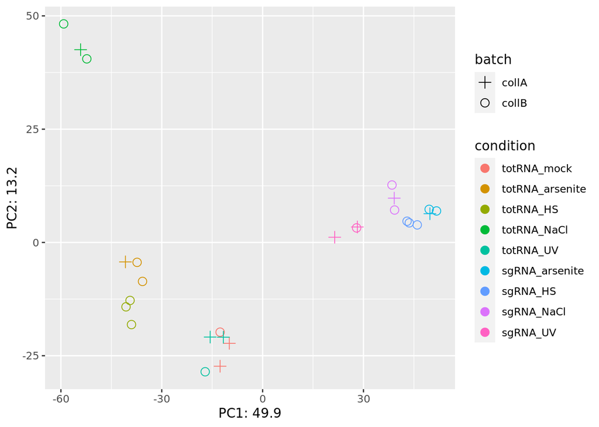

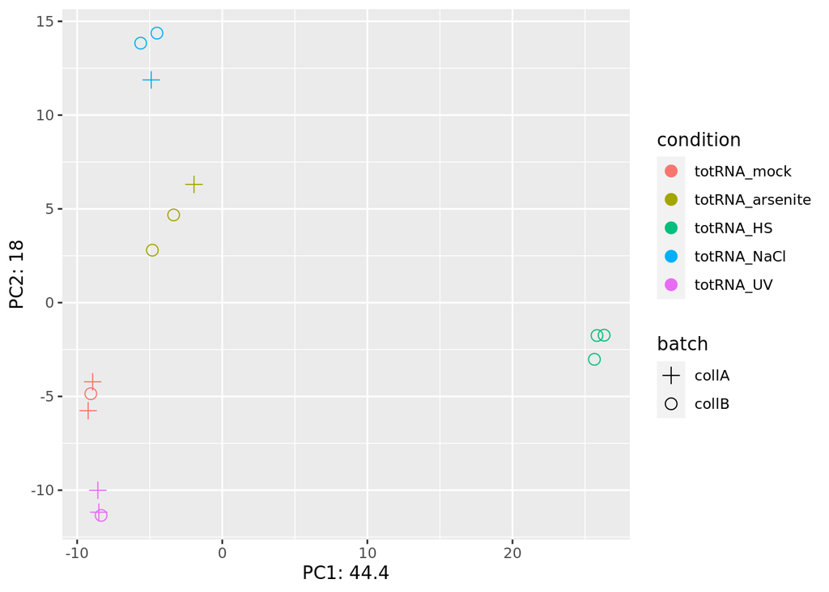

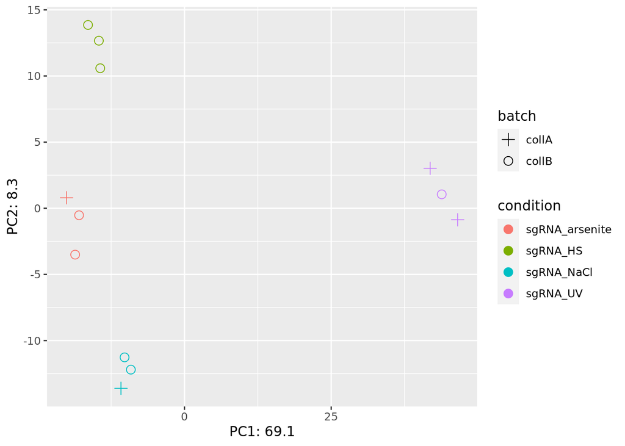

## 3.g) Run DESeq

```r
#res_batch_gene <- DESeq2::DESeq(dds_batch_gene)
# plotDispEsts(dds_batch_gene)
```

```r
#res_batch_transcript <- DESeq2::DESeq(dds_batch_transcript)
# plotDispEsts(dds_batch_transcript)
```

# 4. Restart: Create dds filtered object

After filtering the dds object, we are left with:

- for genes: 23305 rows and 27 columns, from 58302 rows and 27 column
- for transcripts: 72279 rows and 27 columns, from 200310 rows and 27 column

```
## -- note: fitType='parametric', but the dispersion trend was not well captured by the
##    function: y = a/x + b, and a local regression fit was automatically substituted.
##    specify fitType='local' or 'mean' to avoid this message next time.
```

# 5. Extract the contrasts for genes totRNA from filtered object

```
## [1] "DE_gene_totRNA_mock_vs_totRNA_arsenite"
## [1] "DE_gene_totRNA_mock_vs_totRNA_HS"
## [1] "DE_gene_totRNA_mock_vs_totRNA_NaCl"
## [1] "DE_gene_totRNA_mock_vs_totRNA_UV"
```

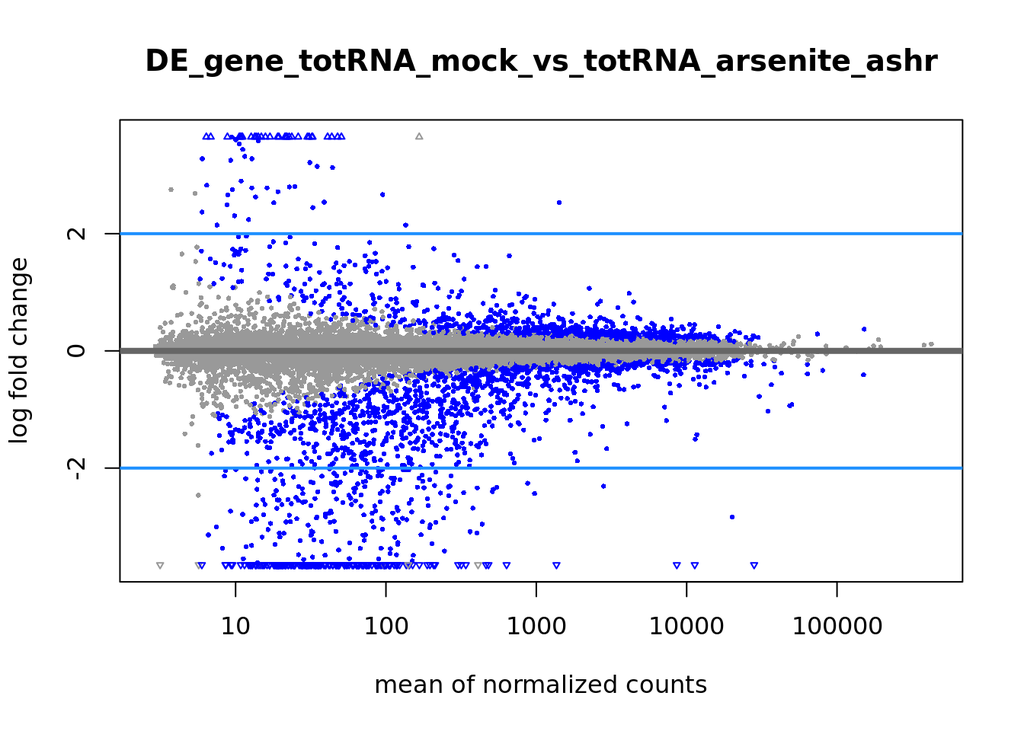

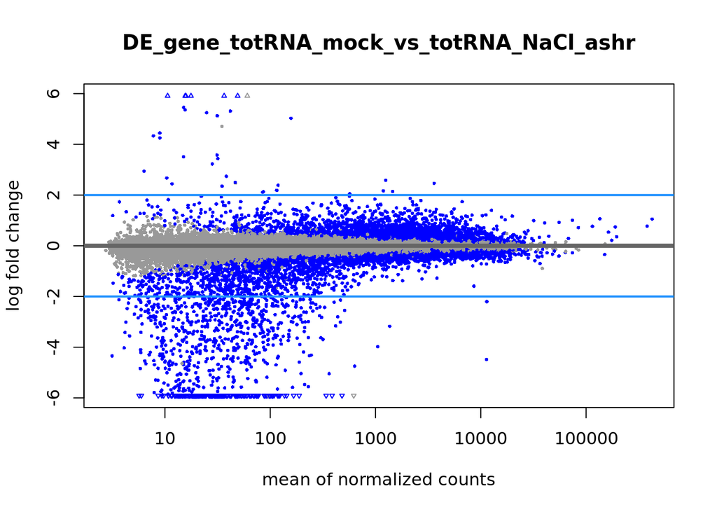

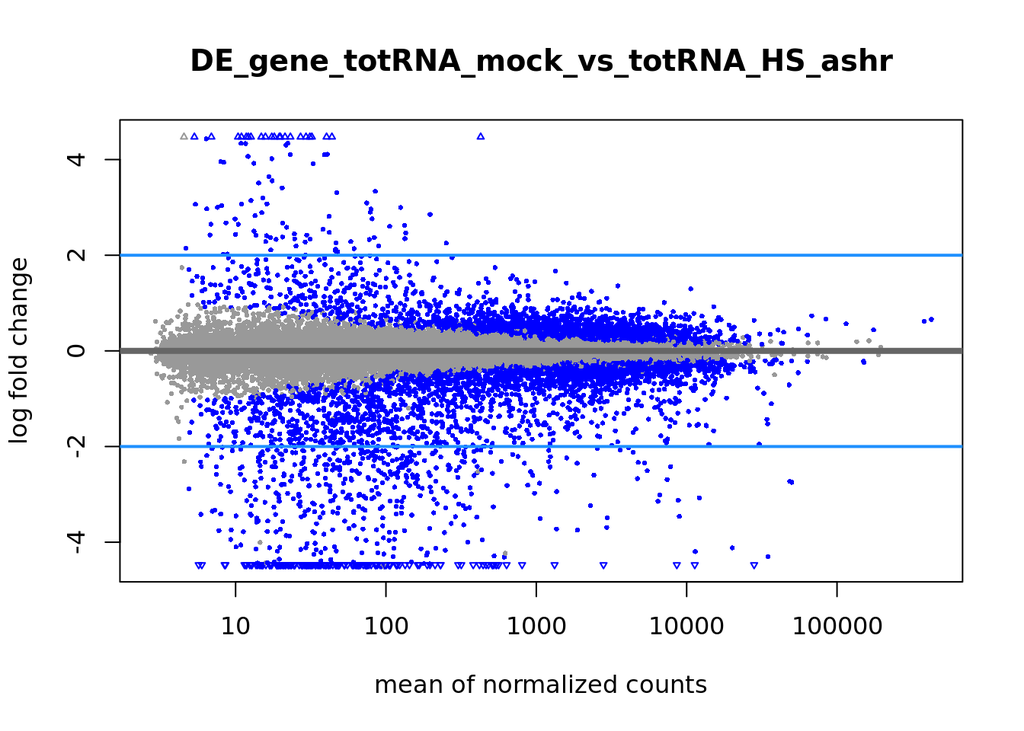

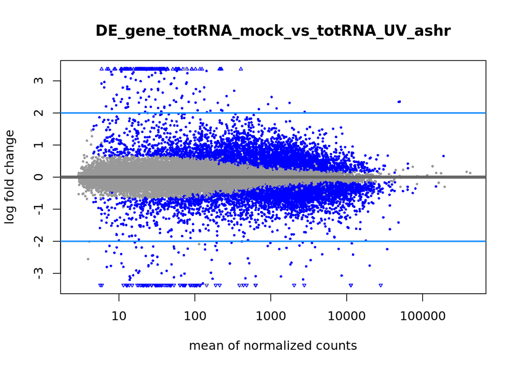

# 6. Extract the contrasts for genes sgRNA from filtered object

```
## [1] "DE_gene_sgRNA_arsenite_vs_sgRNA_HS"
## [1] "DE_gene_sgRNA_arsenite_vs_sgRNA_NaCl"
## [1] "DE_gene_sgRNA_arsenite_vs_sgRNA_UV"
## [1] "DE_gene_sgRNA_HS_vs_sgRNA_NaCl"
## [1] "DE_gene_sgRNA_HS_vs_sgRNA_UV"
## [1] "DE_gene_sgRNA_NaCl_vs_sgRNA_UV"
```

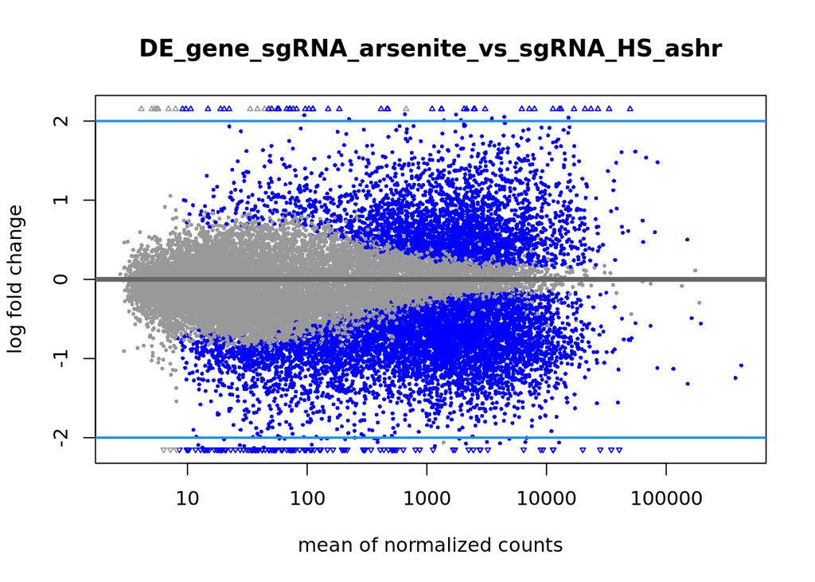

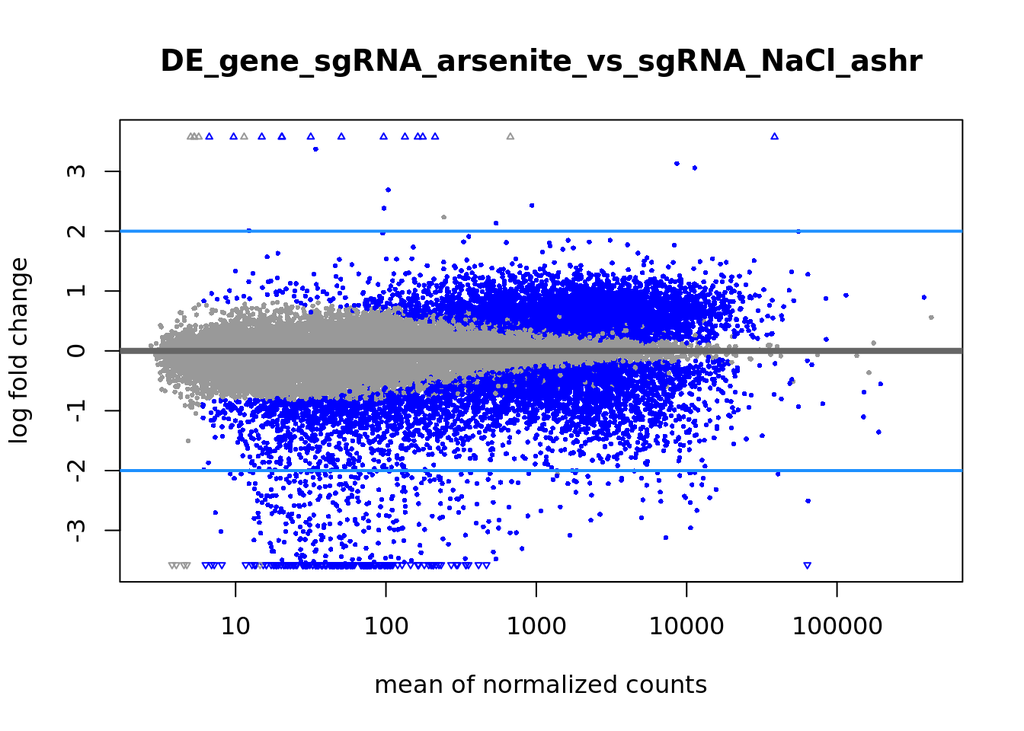

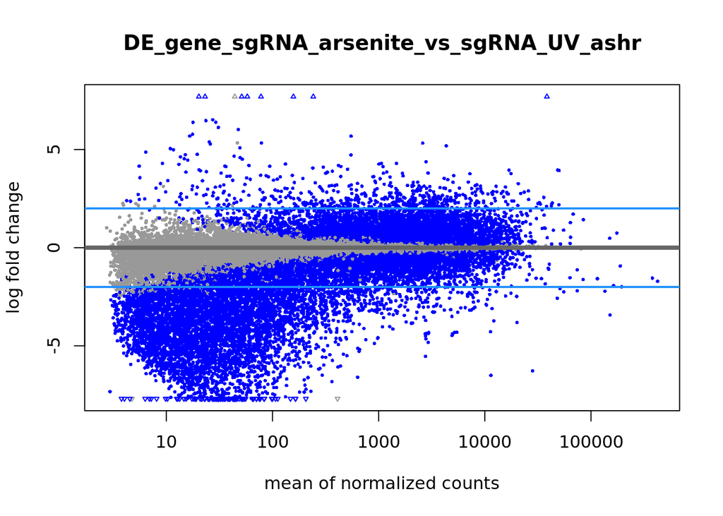

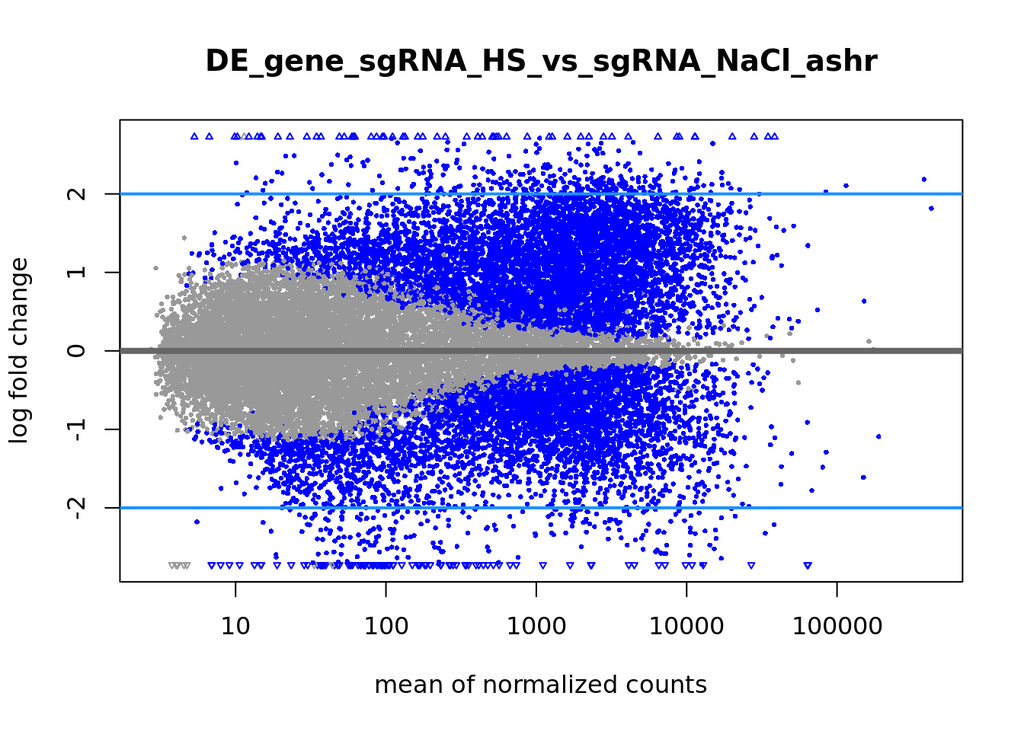

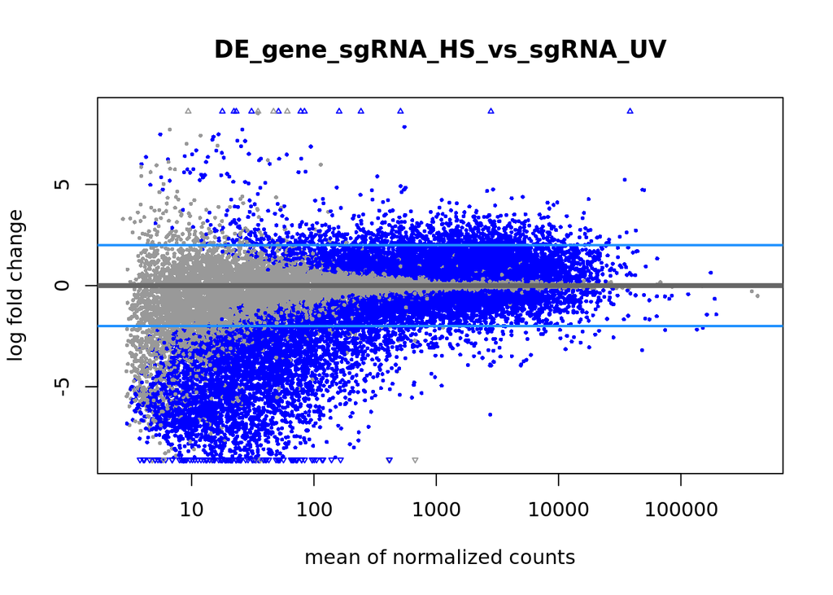

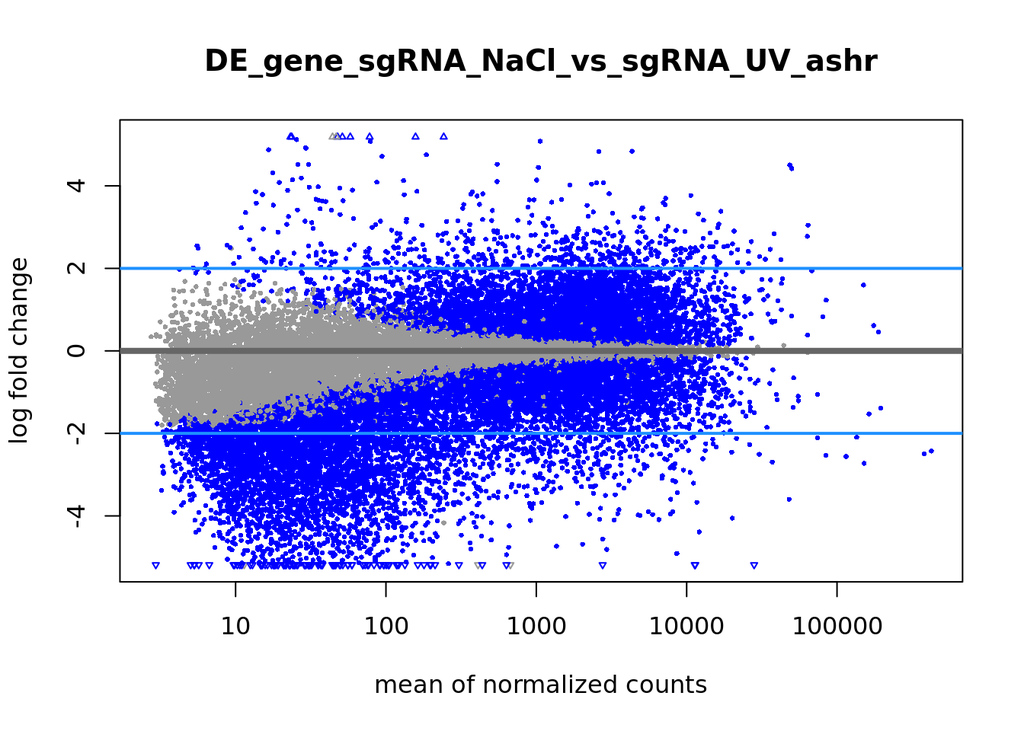

# 7. Extract the contrasts for transcripts totRNA from filtered object

```
## [1] "DE_trans_totRNA_mock_vs_totRNA_arsenite"
## [1] "DE_trans_totRNA_mock_vs_totRNA_HS"
## [1] "DE_trans_totRNA_mock_vs_totRNA_NaCl"
## [1] "DE_trans_totRNA_mock_vs_totRNA_UV"
```

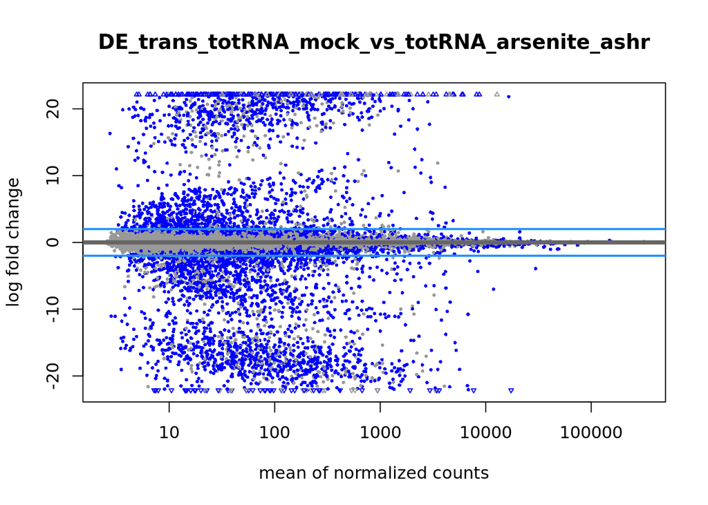

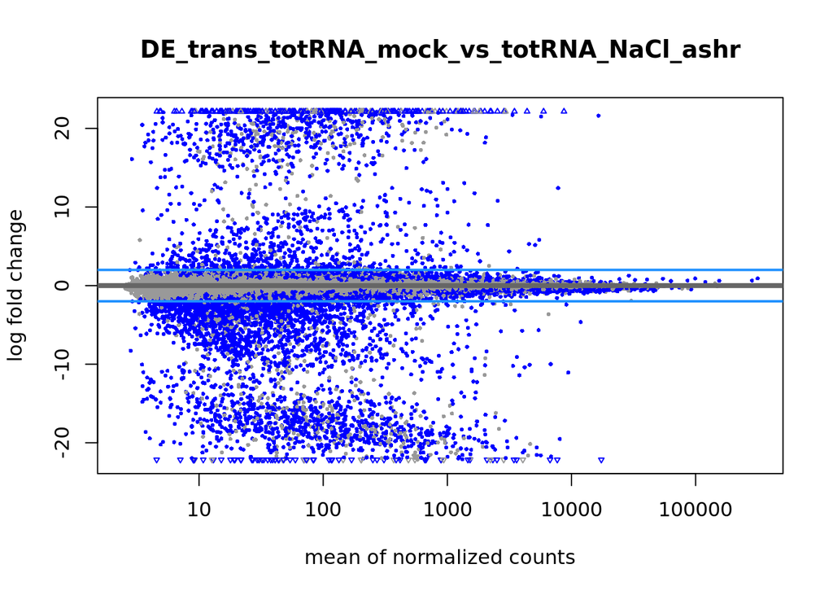

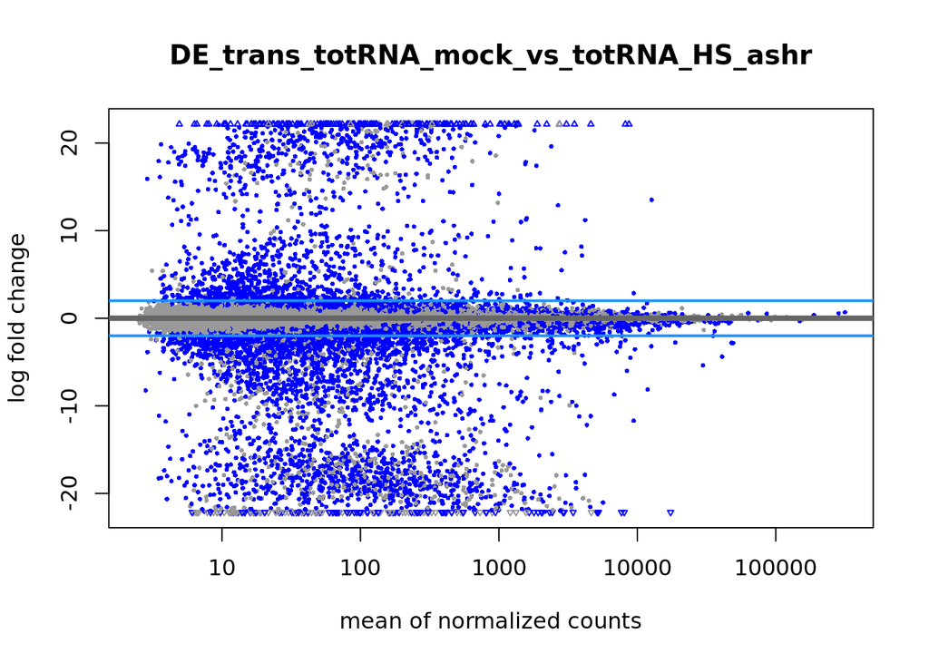

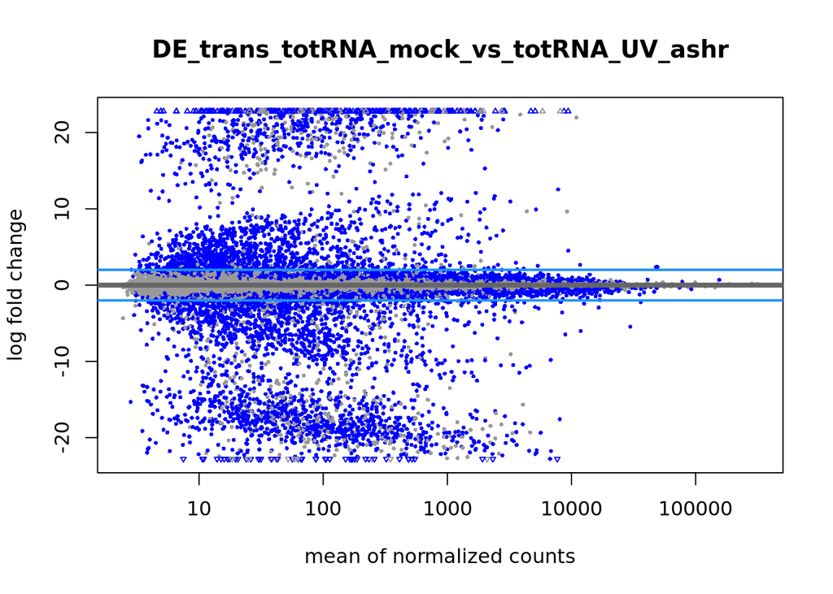

# 8. Extract the contrasts for transcripts sgRNA from filtered object

```
## [1] "DE_trans_sgRNA_arsenite_vs_sgRNA_HS"
## [1] "DE_trans_sgRNA_arsenite_vs_sgRNA_NaCl"
## [1] "DE_trans_sgRNA_arsenite_vs_sgRNA_UV"
## [1] "DE_trans_sgRNA_HS_vs_sgRNA_NaCl"
## [1] "DE_trans_sgRNA_HS_vs_sgRNA_UV"
## [1] "DE_trans_sgRNA_NaCl_vs_sgRNA_UV"
```

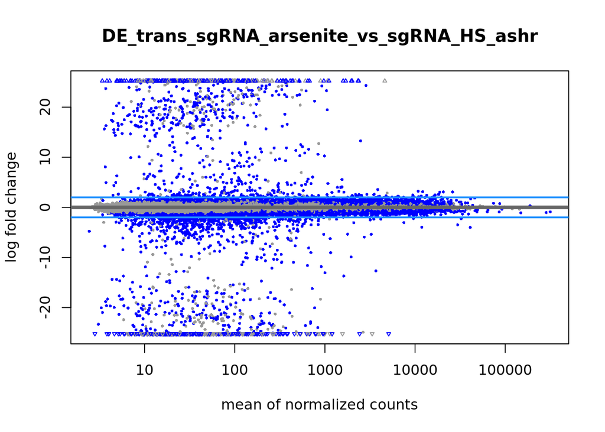

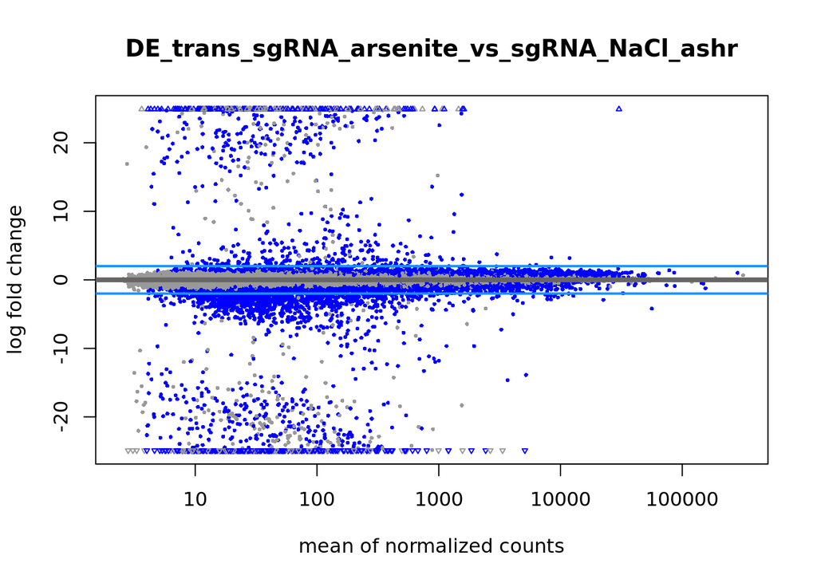

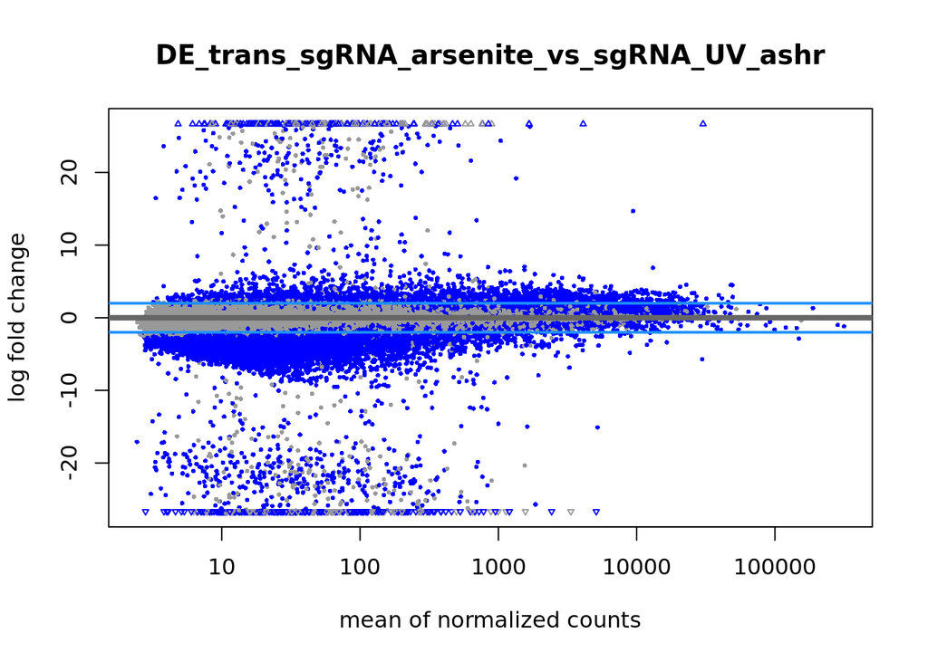

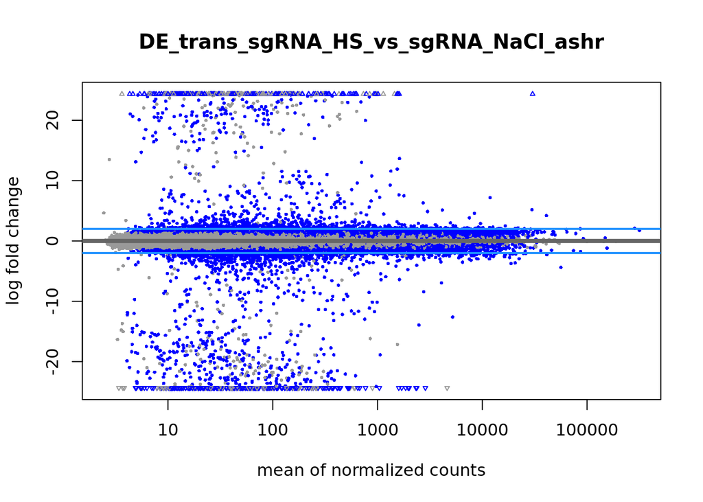

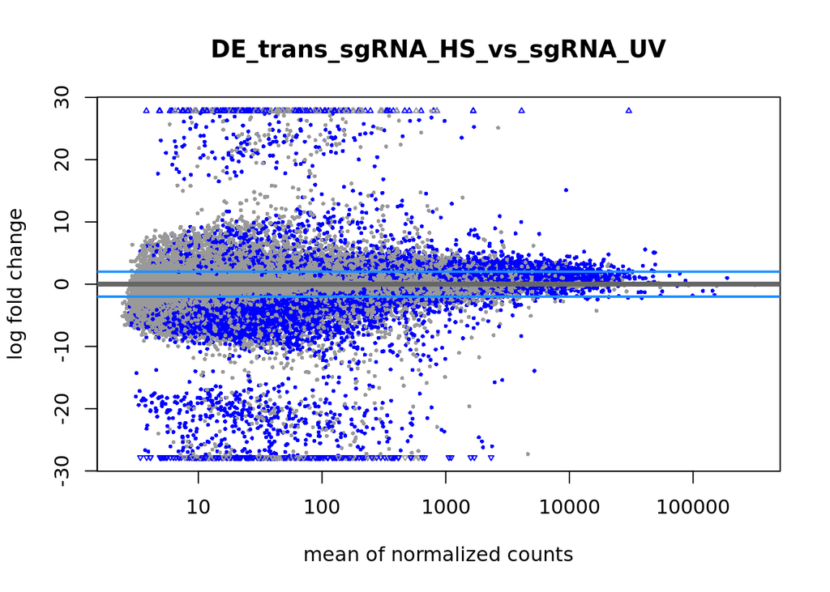

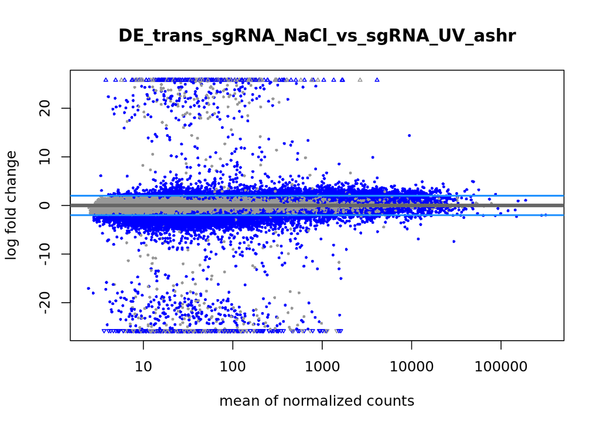

The samples in the transcript sgRNA have very large log2FoldChanges.

# 9. Create the pairwise distance comparisson

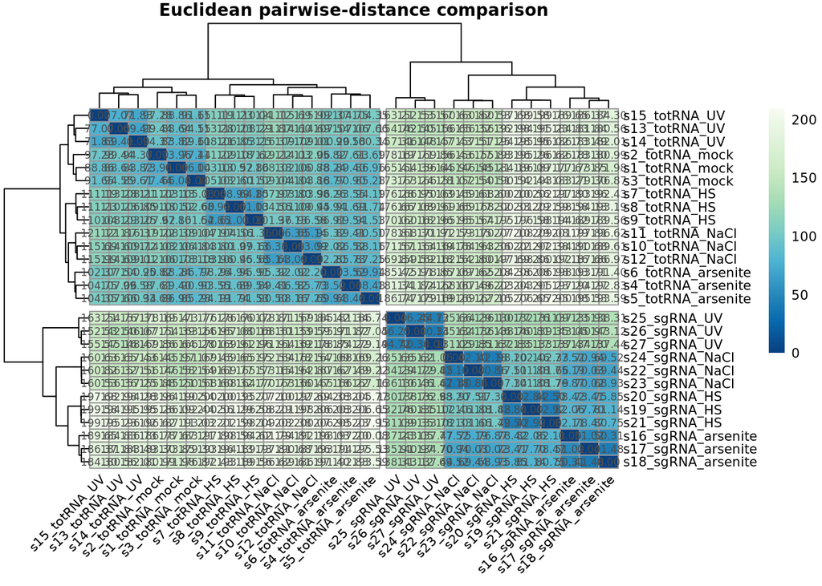

The sgRNA_UV sample group is isolated from the other sgRNA samples = the content of this sample group is distinct from the other sgRNA samples.